# RevisionCompleta

Prosiguiendo, este chunk cruza cada una de las seis variables `BILL_AMT1` a `BILL_AMT6` (montos del estado de cuenta de septiembre a abril de 2005, divididos entre 10.000) contra `SEX`, generando un boxplot por cada mes para comparar el monto del estado de cuenta entre hombres y mujeres mes a mes.

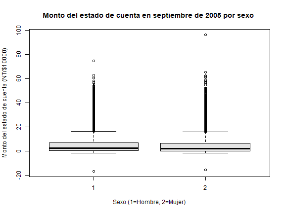

```r
boxplot(BILL_AMT1/10000 ~ SEX, data = datos_credit_visu,
        main = "Monto del estado de cuenta en septiembre de 2005 por sexo ",
        xlab = "Sexo (1=Hombre, 2=Mujer)", ylab = "Monto del estado de cuenta (NT/$10000)",
        col = "grey90")
```

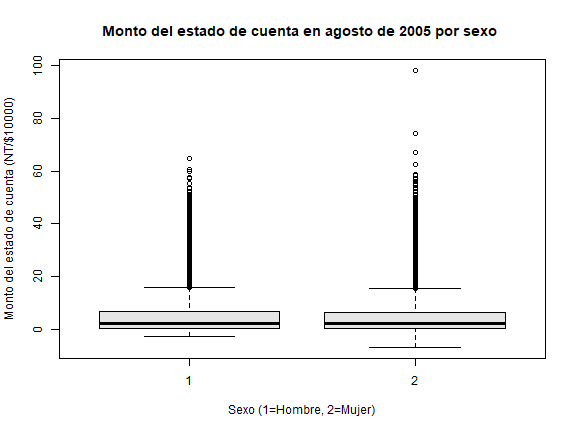

```r
boxplot(BILL_AMT2/10000 ~ SEX, data = datos_credit_visu,
        main = "Monto del estado de cuenta en agosto de 2005 por sexo ",
        xlab = "Sexo (1=Hombre, 2=Mujer)", ylab = "Monto del estado de cuenta (NT/$10000)",
        col = "grey90")
```

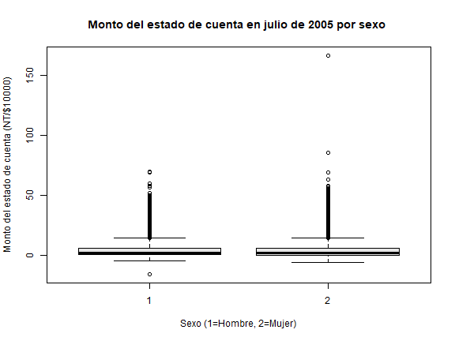

```r
boxplot(BILL_AMT3/10000 ~ SEX, data = datos_credit_visu,
        main = "Monto del estado de cuenta en julio de 2005 por sexo ",
        xlab = "Sexo (1=Hombre, 2=Mujer)", ylab = "Monto del estado de cuenta (NT/$10000)",
        col = "grey90")
```

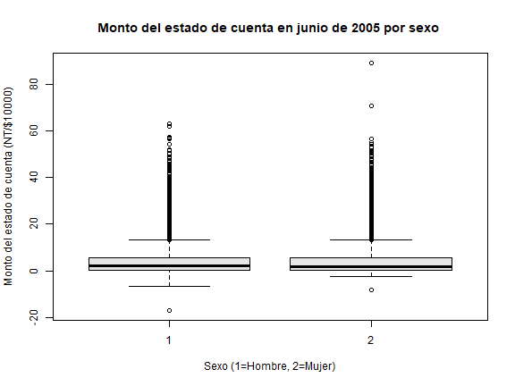

```r
boxplot(BILL_AMT4/10000 ~ SEX, data = datos_credit_visu,
        main = "Monto del estado de cuenta en junio de 2005 por sexo ",
        xlab = "Sexo (1=Hombre, 2=Mujer)", ylab = "Monto del estado de cuenta (NT/$10000)",
        col = "grey90")
```

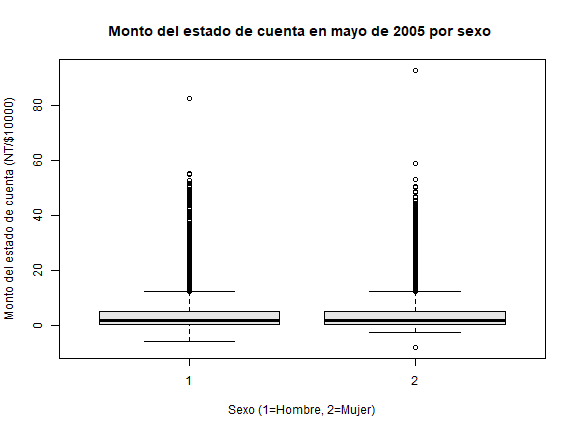

```r
boxplot(BILL_AMT5/10000 ~ SEX, data = datos_credit_visu,
        main = "Monto del estado de cuenta en mayo de 2005 por sexo ",
        xlab = "Sexo (1=Hombre, 2=Mujer)", ylab = "Monto del estado de cuenta (NT/$10000)",
        col = "grey90")
```

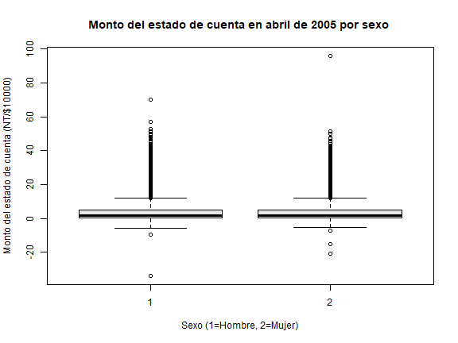

```r
boxplot(BILL_AMT6/10000 ~ SEX, data = datos_credit_visu,
        main = "Monto del estado de cuenta en abril de 2005 por sexo ",
        xlab = "Sexo (1=Hombre, 2=Mujer)", ylab = "Monto del estado de cuenta (NT/$10000)",
        col = "grey90")
```

Los seis meses muestran lo mismo: hombres y mujeres tienen distribuciones prácticamente idénticas. Medianas cercanas a 2 unidades de NT/$10.000 en ambos grupos, cajas que van de 0 a 6 aproximadamente, y bigotes superiores que coinciden entre los dos sexos en cada mes. El sexo no separa esta variable.

Cada panel tiene un eje vertical distinto (julio llega a 150, junio a 80), así que comparar meses a simple vista engaña.

En los seis casos la forma es la misma: asimetría positiva fuerte, mediana pegada al borde inferior de la caja, y una columna densa y continua de atípicos hasta 50-60 unidades.

El máximo siempre está en el grupo 2. Julio es el caso extremo: 166 en mujeres frente a 70 en hombres. Pero las mujeres son el grupo más numeroso del dataset, y a más observaciones, más probabilidad de extremos; el boxplot no muestra ese tamaño, así que el patrón puede ser solo eso.

Hay valores negativos en ambos grupos todos los meses. El más profundo es aproximadamente -34 en hombres en abril.

Ahora, este chunk cruza las seis variables `PAY_AMT1` a `PAY_AMT6` (montos efectivamente pagados por el cliente de septiembre a abril de 2005, divididos entre 10.000) contra `SEX`, para comparar cuánto pagaron efectivamente hombres y mujeres cada mes.

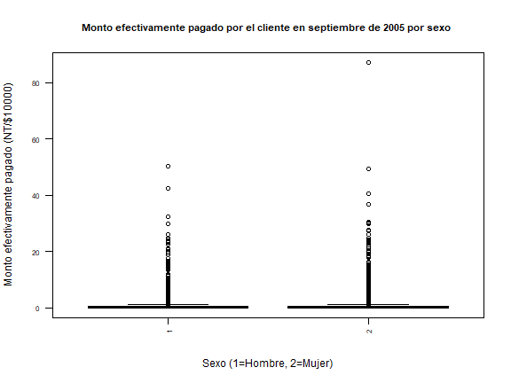

```r
boxplot(PAY_AMT1/10000 ~ SEX, data = datos_credit_visu,
        main = "Monto efectivamente pagado por el cliente en septiembre de 2005 por sexo ",
        las = 2,
        cex.axis = 0.7,
        cex.main = 0.9,
        xlab = "Sexo (1=Hombre, 2=Mujer)", ylab = "Monto efectivamente pagado (NT/$10000)",
        col = "grey90")
```

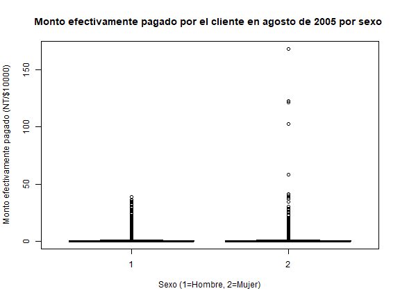

```r
boxplot(PAY_AMT2/10000 ~ SEX, data = datos_credit_visu,
        main = "Monto efectivamente pagado por el cliente en agosto de 2005 por sexo ",
        xlab = "Sexo (1=Hombre, 2=Mujer)", ylab = "Monto efectivamente pagado (NT/$10000)",
        col = "grey90")
```

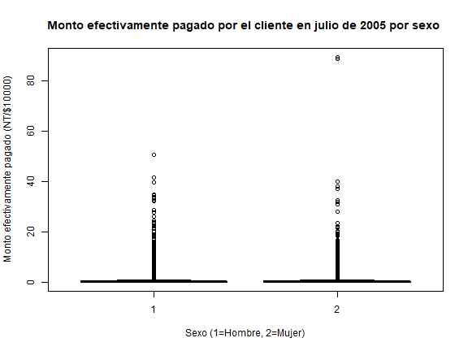

```r
boxplot(PAY_AMT3/10000 ~ SEX, data = datos_credit_visu,
        main = "Monto efectivamente pagado por el cliente en julio de 2005 por sexo ",
        xlab = "Sexo (1=Hombre, 2=Mujer)", ylab = "Monto efectivamente pagado (NT/$10000)",
        col = "grey90")
```

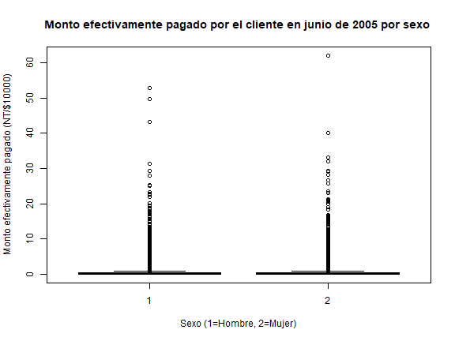

```r
boxplot(PAY_AMT4/10000 ~ SEX, data = datos_credit_visu,
        main = "Monto efectivamente pagado por el cliente en junio de 2005 por sexo ",
        xlab = "Sexo (1=Hombre, 2=Mujer)", ylab = "Monto efectivamente pagado (NT/$10000)",
        col = "grey90")
```

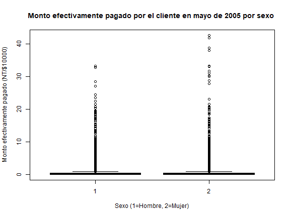

```r
boxplot(PAY_AMT5/10000 ~ SEX, data = datos_credit_visu,
        main = "Monto efectivamente pagado por el cliente en mayo de 2005 por sexo ",
        xlab = "Sexo (1=Hombre, 2=Mujer)", ylab = "Monto efectivamente pagado (NT/$10000)",
        col = "grey90")
```

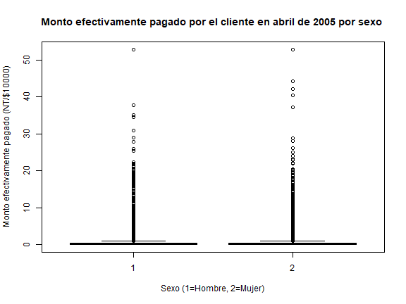

```r
boxplot(PAY_AMT6/10000 ~ SEX, data = datos_credit_visu,
        main = "Monto efectivamente pagado por el cliente en abril de 2005 por sexo ",
        xlab = "Sexo (1=Hombre, 2=Mujer)", ylab = "Monto efectivamente pagado (NT/$10000)",
        col = "grey90")
```

Las cajas están colapsadas sobre cero en los dos grupos y en los seis meses. No se distingue mediana ni cuartiles: todo el rango intercuartílico cabe en menos de 1 unidad de NT/$10.000. El bigote superior llega a cerca de 1 unidad (NT$10.000). Sexo y mes son irrelevantes para esto: las doce cajas se ven iguales.

Toda la información está en los atípicos. Forman una columna vertical densa desde cero hasta unas 20-25 unidades, y encima puntos sueltos.

Cinco de seis meses tienen el máximo en mujeres. Agosto es el caso extremo: 168 frente a 40, con cuatro puntos aislados en el grupo 2 (168, 122, 102, 58) que no tienen contraparte en hombres.

Ojo con las escalas: cada panel tiene eje propio (agosto llega a 150, mayo a 40). La columna de atípicos de mayo parece más alta que la de agosto solo por eso.

Comparado con BILL_AMT: allí las cajas eran visibles y había negativos. Aquí no. La asimetría de PAY_AMT es mucho más severa.

### 3.2.3 De “EDUCATION”

En esta sección se cruza la variable categórica `EDUCATION` (nivel educativo del cliente, convertida a factor) contra las mismas variables numéricas utilizadas en la sección anterior, para observar si el nivel educativo se relaciona con diferencias en el crédito otorgado, la edad, los montos de estado de cuenta y los montos pagados.

Se cruza `LIMIT_BAL` (monto de crédito otorgado, en unidades de 10.000) contra `EDUCATION`, para ver si el monto de crédito varía según el nivel educativo. Nótese el comentario original del equipo señalando la necesidad de revisar el significado de las categorías 0, 5 y 6 de `EDUCATION`, que no están claramente documentadas en el diccionario de datos.

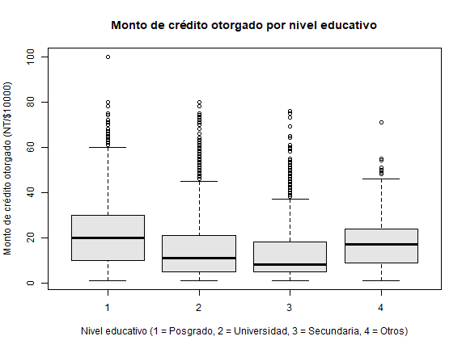

```r
boxplot(LIMIT_BAL/10000 ~ EDUCATION, data = datos_credit_visu, #CHICOS FAVOR MIRAR ESTE K SIGNIFICA 5 Y 6 Y 0 XDDD
        main = "Monto de crédito otorgado por nivel educativo",
        xlab = "Nivel educativo (1 = Posgrado, 2 = Universidad, 3 = Secundaria, 4 = Otros)", ylab = "Monto de crédito otorgado (NT/$10000)",
        col = "grey90")
```

Gráfico con diferencias claras. Medianas: 20 (posgrado), 11 (universidad), 8 (secundaria), 17 (otros). Cajas: 10-30, 5-21, 5-18, 9-24. Hay gradiente descendente 1→2→3: a menor nivel educativo, menor cupo. El grupo 4 se ubica entre 1 y 2. Los bigotes superiores siguen el mismo orden: 60, 45, 37, 46.

Se cruza `AGE` contra `EDUCATION`, para observar cómo se distribuye la edad de los clientes según su nivel educativo.

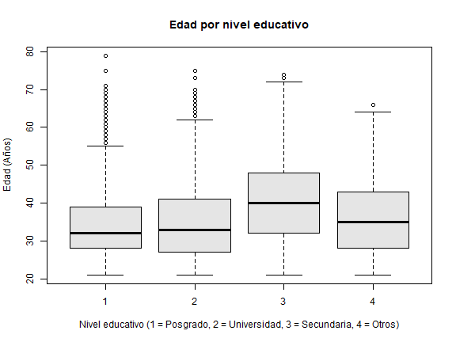

```r
boxplot(AGE ~ EDUCATION, data = datos_credit_visu,
        main = "Edad por nivel educativo",
        xlab = "Nivel educativo (1 = Posgrado, 2 = Universidad, 3 = Secundaria, 4 = Otros)", ylab = "Edad (Años)",
        col = "grey90")
```

Diferencia visible en sentido inverso. Medianas: 32, 33, 40, 35. El grupo 3 es claramente mayor y más disperso (caja 32-48, contra 28-39 en el grupo 1). Al analizar también con LIMIT_BAL, el grupo con menor cupo es también el de más edad.

Se cruzan `BILL_AMT1` a `BILL_AMT6` (montos del estado de cuenta de septiembre a abril de 2005) contra `EDUCATION`, generando un boxplot por mes para comparar el monto del estado de cuenta según el nivel educativo del cliente.

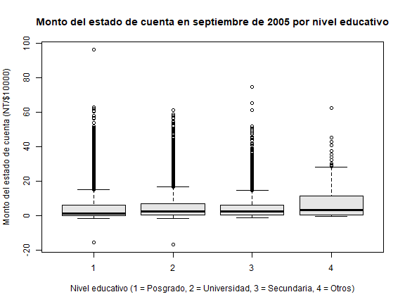

```r
boxplot(BILL_AMT1/10000 ~ EDUCATION, data = datos_credit_visu,
        main = "Monto del estado de cuenta en septiembre de 2005 por nivel educativo",
        xlab = "Nivel educativo (1 = Posgrado, 2 = Universidad, 3 = Secundaria, 4 = Otros)", ylab = "Monto del estado de cuenta (NT/$10000)",
        col = "grey90")
```

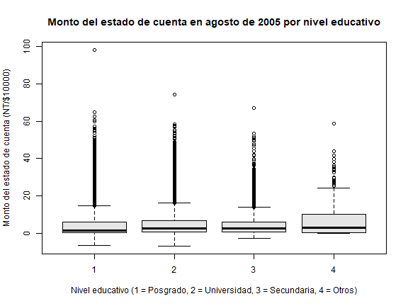

```r
boxplot(BILL_AMT2/10000 ~ EDUCATION, data = datos_credit_visu,
        main = "Monto del estado de cuenta en agosto de 2005 por nivel educativo",
        xlab = "Nivel educativo (1 = Posgrado, 2 = Universidad, 3 = Secundaria, 4 = Otros)", ylab = "Monto del estado de cuenta (NT/$10000)",
        col = "grey90")
```

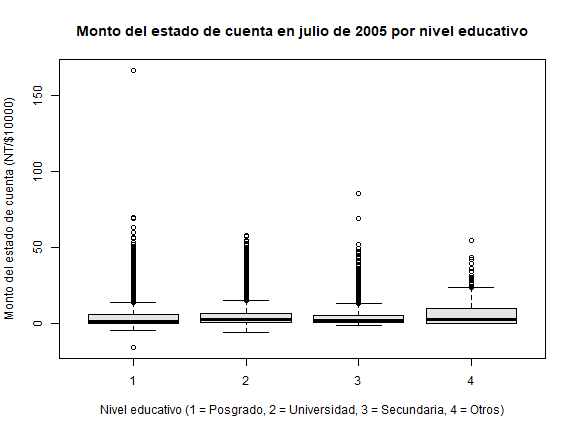

```r
boxplot(BILL_AMT3/10000 ~ EDUCATION, data = datos_credit_visu,
        main = "Monto del estado de cuenta en julio de 2005 por nivel educativo",
        xlab = "Nivel educativo (1 = Posgrado, 2 = Universidad, 3 = Secundaria, 4 = Otros)", ylab = "Monto del estado de cuenta (NT/$10000)",
        col = "grey90")
```

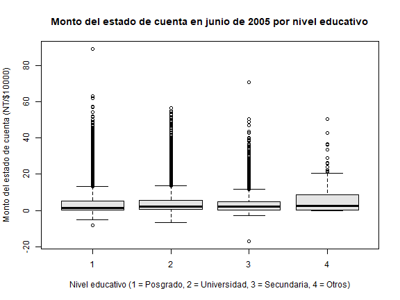

```r
boxplot(BILL_AMT4/10000 ~ EDUCATION, data = datos_credit_visu,
        main = "Monto del estado de cuenta en junio de 2005 por nivel educativo",
        xlab = "Nivel educativo (1 = Posgrado, 2 = Universidad, 3 = Secundaria, 4 = Otros)", ylab = "Monto del estado de cuenta (NT/$10000)",
        col = "grey90")
```

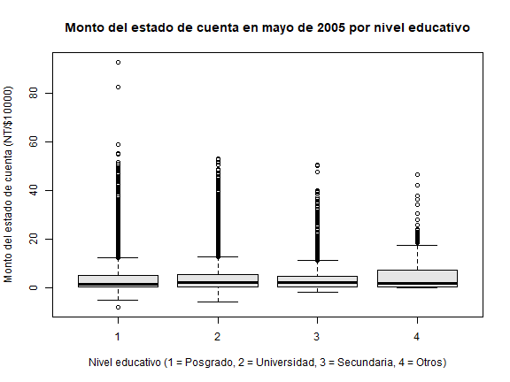

```r
boxplot(BILL_AMT5/10000 ~ EDUCATION, data = datos_credit_visu,
        main = "Monto del estado de cuenta en mayo de 2005 por nivel educativo",
        xlab = "Nivel educativo (1 = Posgrado, 2 = Universidad, 3 = Secundaria, 4 = Otros)", ylab = "Monto del estado de cuenta (NT/$10000)",
        col = "grey90")
```

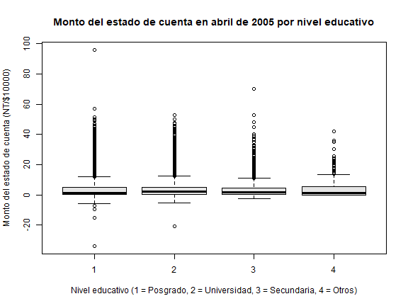

```r
boxplot(BILL_AMT6/10000 ~ EDUCATION, data = datos_credit_visu,
        main = "Monto del estado de cuenta en abril de 2005 por nivel educativo",
        xlab = "Nivel educativo (1 = Posgrado, 2 = Universidad, 3 = Secundaria, 4 = Otros)", ylab = "Monto del estado de cuenta (NT/$10000)",
        col = "grey90")
```

Se cruzan `PAY_AMT1` a `PAY_AMT6` (montos efectivamente pagados de septiembre a abril de 2005) contra `EDUCATION`, para comparar cuánto pagaron efectivamente los clientes según su nivel educativo, mes a mes.

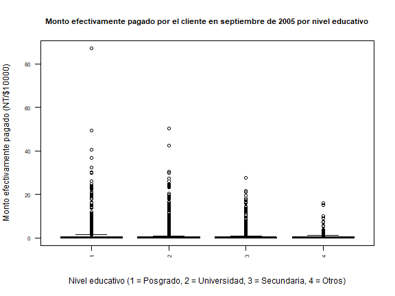

```r
boxplot(PAY_AMT1/10000 ~ EDUCATION, data = datos_credit_visu,
        main = "Monto efectivamente pagado por el cliente en septiembre de 2005 por nivel educativo",
        las = 2,
        cex.axis = 0.7,
        cex.main = 0.9,
        xlab = "Nivel educativo (1 = Posgrado, 2 = Universidad, 3 = Secundaria, 4 = Otros)", ylab = "Monto efectivamente pagado (NT/$10000)",
        col = "grey90")
```

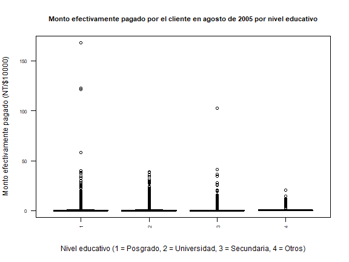

```r
boxplot(PAY_AMT2/10000 ~ EDUCATION, data = datos_credit_visu,
        main = "Monto efectivamente pagado por el cliente en agosto de 2005 por nivel educativo",
        las = 2,
        cex.axis = 0.7,
        cex.main = 0.9,
        xlab = "Nivel educativo (1 = Posgrado, 2 = Universidad, 3 = Secundaria, 4 = Otros)", ylab = "Monto efectivamente pagado (NT/$10000)",
        col = "grey90")
```

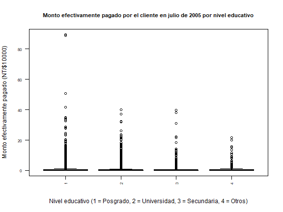

```r
boxplot(PAY_AMT3/10000 ~ EDUCATION, data = datos_credit_visu,
        main = "Monto efectivamente pagado por el cliente en julio de 2005 por nivel educativo",
        las = 2,
        cex.axis = 0.7,
        cex.main = 0.9,
        xlab = "Nivel educativo (1 = Posgrado, 2 = Universidad, 3 = Secundaria, 4 = Otros)", ylab = "Monto efectivamente pagado (NT/$10000)",
        col = "grey90")
```

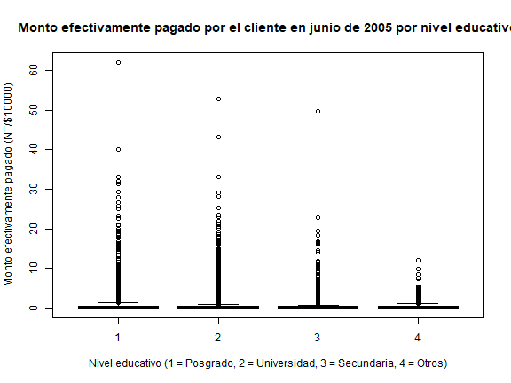

```r
boxplot(PAY_AMT4/10000 ~ EDUCATION, data = datos_credit_visu,
        main = "Monto efectivamente pagado por el cliente en junio de 2005 por nivel educativo",
        xlab = "Nivel educativo (1 = Posgrado, 2 = Universidad, 3 = Secundaria, 4 = Otros)", ylab = "Monto efectivamente pagado (NT/$10000)",
        col = "grey90")
```

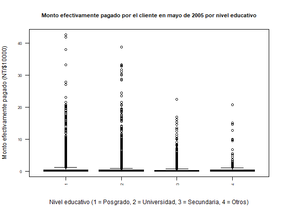

```r
boxplot(PAY_AMT5/10000 ~ EDUCATION, data = datos_credit_visu,
        main = "Monto efectivamente pagado por el cliente en mayo de 2005 por nivel educativo",
        las = 2,
        cex.axis = 0.7,
        cex.main = 0.9,
        xlab = "Nivel educativo (1 = Posgrado, 2 = Universidad, 3 = Secundaria, 4 = Otros)", ylab = "Monto efectivamente pagado (NT/$10000)",
        col = "grey90")
```

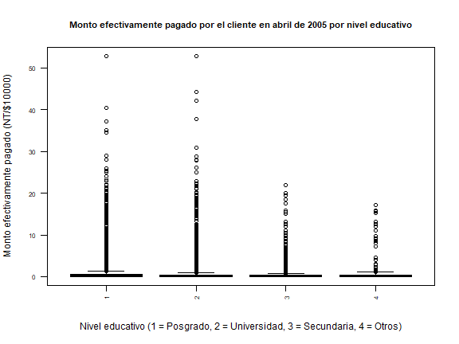

```r
boxplot(PAY_AMT6/10000 ~ EDUCATION, data = datos_credit_visu,
        main = "Monto efectivamente pagado por el cliente en abril de 2005 por nivel educativo",
        las = 2,
        cex.axis = 0.7,
        cex.main = 0.9,
        xlab = "Nivel educativo (1 = Posgrado, 2 = Universidad, 3 = Secundaria, 4 = Otros)", ylab = "Monto efectivamente pagado (NT/$10000)",
        col = "grey90")
```

**Finalmente, se concluye que el nivel educativo discrimina el cupo otorgado y la edad, pero no el saldo ni el pago.**

### 3.2.4 De “MARRIAGE”

En esta sección se cruza la variable categórica `MARRIAGE` (estado civil del cliente, convertida a factor) contra las mismas variables numéricas, para explorar si el estado civil se asocia con diferencias en el crédito otorgado, la edad, los montos de estado de cuenta y los montos pagados.

Se cruza `LIMIT_BAL` contra `MARRIAGE`, para comparar el monto de crédito otorgado según el estado civil del cliente.

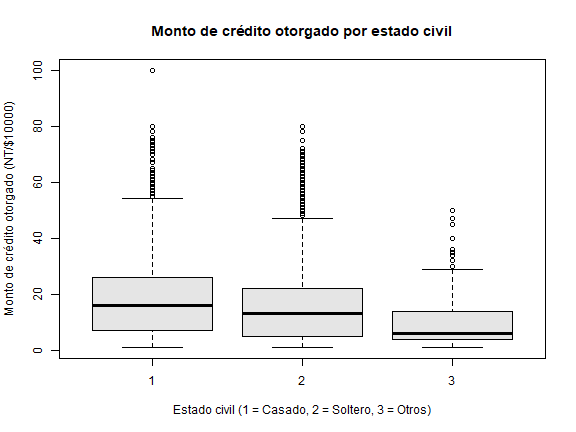

```r
boxplot(LIMIT_BAL/10000 ~ MARRIAGE, data = datos_credit_visu,
        main = "Monto de crédito otorgado por estado civil",
        xlab = "Estado civil (1 = Casado, 2 = Soltero, 3 = Otros)", ylab = "Monto de crédito otorgado (NT/$10000)",
        col = "grey90")
```

En este boxplot se puede apreciar una posible relación entre el monto de crédito que recibe una persona y su estado civil. Las personas casadas son las que tienen mayor cupo, los solteros quedan apenas por debajo, y el grupo “Otros” (posiblemente separados, viudos, etc) está notoriamente más abajo y con menos dispersión.

Se cruza `AGE` contra `MARRIAGE`, para observar la distribución de edades según el estado civil.

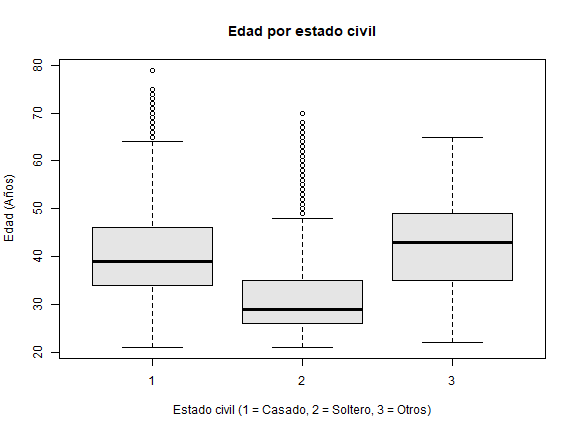

```r
boxplot(AGE ~ MARRIAGE, data = datos_credit_visu,
        main = "Edad por estado civil",
        xlab = "Estado civil (1 = Casado, 2 = Soltero, 3 = Otros)", ylab = "Edad (Años)",
        col = "grey90")
```

Los solteros son claramente el grupo más joven y más compacto; casados y “Otros” están desplazados hacia edades mayores, siendo “Otros” el de mediana más alta y el más disperso; se asemeja algo a una distribución normal.

Se cruzan `BILL_AMT1` a `BILL_AMT6` contra `MARRIAGE`, generando un boxplot por mes para comparar el monto del estado de cuenta según el estado civil del cliente.

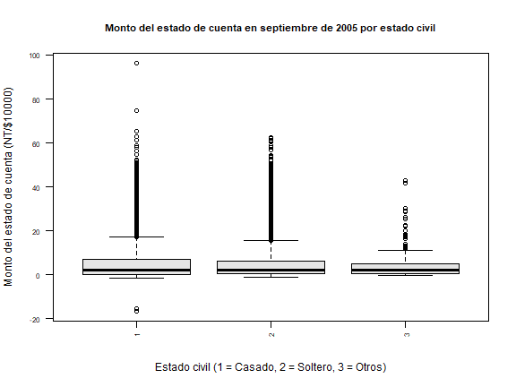

```r
boxplot(BILL_AMT1/10000 ~ MARRIAGE, data = datos_credit_visu,
        main = "Monto del estado de cuenta en septiembre de 2005 por estado civil",
        las = 2,
        cex.axis = 0.7,
        cex.main = 0.9,
        xlab = "Estado civil (1 = Casado, 2 = Soltero, 3 = Otros)", ylab = "Monto del estado de cuenta (NT/$10000)",
        col = "grey90")
```

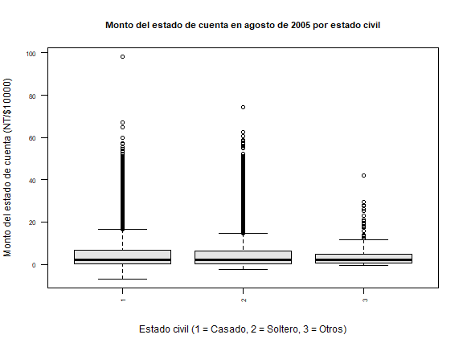

```r
boxplot(BILL_AMT2/10000 ~ MARRIAGE, data = datos_credit_visu,
        main = "Monto del estado de cuenta en agosto de 2005 por estado civil",
        las = 2,
        cex.axis = 0.7,
        cex.main = 0.9,
        xlab = "Estado civil (1 = Casado, 2 = Soltero, 3 = Otros)", ylab = "Monto del estado de cuenta (NT/$10000)",
        col = "grey90")
```

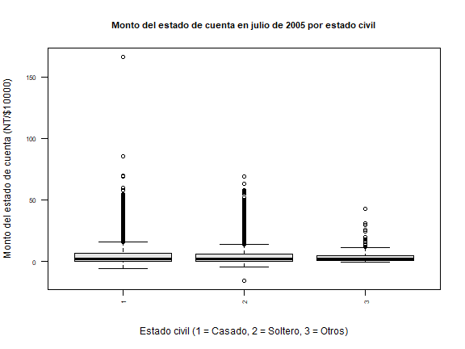

```r
boxplot(BILL_AMT3/10000 ~ MARRIAGE, data = datos_credit_visu,
        main = "Monto del estado de cuenta en julio de 2005 por estado civil",
        las = 2,
        cex.axis = 0.7,
        cex.main = 0.9,
        xlab = "Estado civil (1 = Casado, 2 = Soltero, 3 = Otros)", ylab = "Monto del estado de cuenta (NT/$10000)",
        col = "grey90")
```

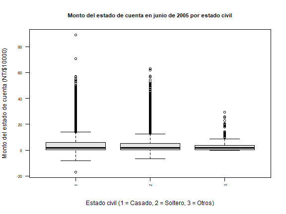

```r
boxplot(BILL_AMT4/10000 ~ MARRIAGE, data = datos_credit_visu,
        main = "Monto del estado de cuenta en junio de 2005 por estado civil",
        las = 2,
        cex.axis = 0.7,
        cex.main = 0.9,
        xlab = "Estado civil (1 = Casado, 2 = Soltero, 3 = Otros)", ylab = "Monto del estado de cuenta (NT/$10000)",
        col = "grey90")
```

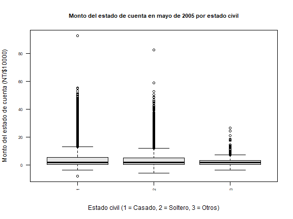

```r
boxplot(BILL_AMT5/10000 ~ MARRIAGE, data = datos_credit_visu,
        main = "Monto del estado de cuenta en mayo de 2005 por estado civil",
        las = 2,
        cex.axis = 0.7,
        cex.main = 0.9,
        xlab = "Estado civil (1 = Casado, 2 = Soltero, 3 = Otros)", ylab = "Monto del estado de cuenta (NT/$10000)",
        col = "grey90")
```

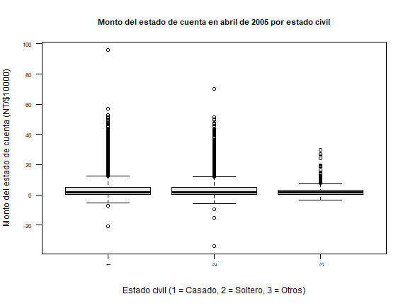

```r
boxplot(BILL_AMT6/10000 ~ MARRIAGE, data = datos_credit_visu,
        main = "Monto del estado de cuenta en abril de 2005 por estado civil",
        las = 2,
        cex.axis = 0.7,
        cex.main = 0.9,
        xlab = "Estado civil (1 = Casado, 2 = Soltero, 3 = Otros)", ylab = "Monto del estado de cuenta (NT/$10000)",
        col = "grey90")
```

Casados y solteros son indistinguibles entre sí en los seis paneles: misma posición, mismo tamaño de caja, misma nube densa de atípicos. “Otros” se ve más recogido, con menos alcance hacia arriba, lo cual responde a su menor número de observaciones más que a un comportamiento distinto. El patrón se repite idéntico mes a mes.

Se cruzan `PAY_AMT1` a `PAY_AMT6` contra `MARRIAGE`, para comparar cuánto pagaron efectivamente los clientes según su estado civil, mes a mes.

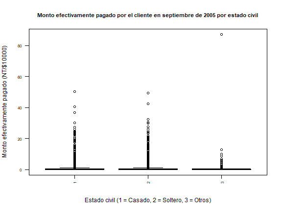

```r
boxplot(PAY_AMT1/10000 ~ MARRIAGE, data = datos_credit_visu,
        main = "Monto efectivamente pagado por el cliente en septiembre de 2005 por estado civil",
        las = 2,
        cex.axis = 0.7,
        cex.main = 0.9,
        xlab = "Estado civil (1 = Casado, 2 = Soltero, 3 = Otros)", ylab = "Monto efectivamente pagado (NT/$10000)",
        col = "grey90")
```

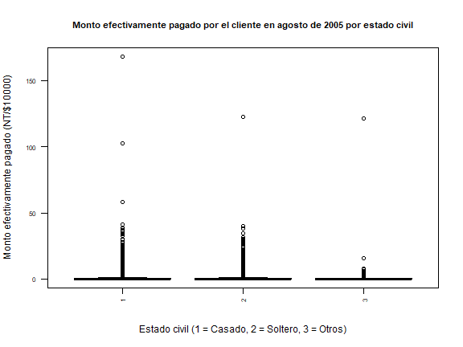

```r
boxplot(PAY_AMT2/10000 ~ MARRIAGE, data = datos_credit_visu,
        main = "Monto efectivamente pagado por el cliente en agosto de 2005 por estado civil",
        las = 2,
        cex.axis = 0.7,
        cex.main = 0.9,
        xlab = "Estado civil (1 = Casado, 2 = Soltero, 3 = Otros)", ylab = "Monto efectivamente pagado (NT/$10000)",
        col = "grey90")
```

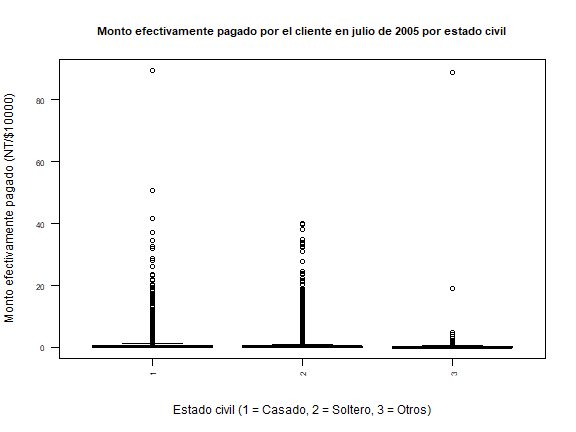

```r
boxplot(PAY_AMT3/10000 ~ MARRIAGE, data = datos_credit_visu,
        main = "Monto efectivamente pagado por el cliente en julio de 2005 por estado civil",
        las = 2,
        cex.axis = 0.7,
        cex.main = 0.9,
        xlab = "Estado civil (1 = Casado, 2 = Soltero, 3 = Otros)", ylab = "Monto efectivamente pagado (NT/$10000)",
        col = "grey90")
```

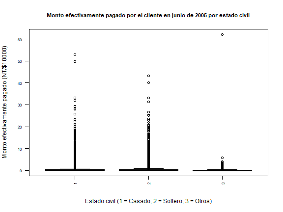

```r
boxplot(PAY_AMT4/10000 ~ MARRIAGE, data = datos_credit_visu,
        main = "Monto efectivamente pagado por el cliente en junio de 2005 por estado civil",
        las = 2,
        cex.axis = 0.7,
        cex.main = 0.9,
        xlab = "Estado civil (1 = Casado, 2 = Soltero, 3 = Otros)", ylab = "Monto efectivamente pagado (NT/$10000)",
        col = "grey90")
```

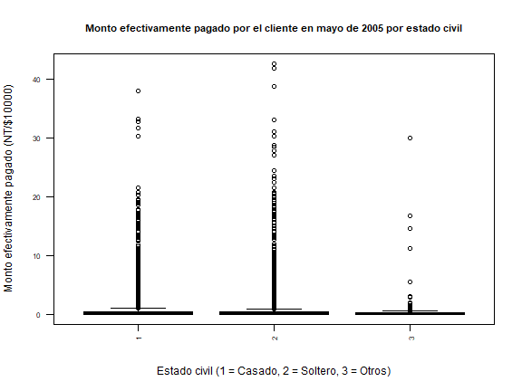

```r
boxplot(PAY_AMT5/10000 ~ MARRIAGE, data = datos_credit_visu,
        main = "Monto efectivamente pagado por el cliente en mayo de 2005 por estado civil",
        las = 2,
        cex.axis = 0.7,
        cex.main = 0.9,
        xlab = "Estado civil (1 = Casado, 2 = Soltero, 3 = Otros)", ylab = "Monto efectivamente pagado (NT/$10000)",
        col = "grey90")
```

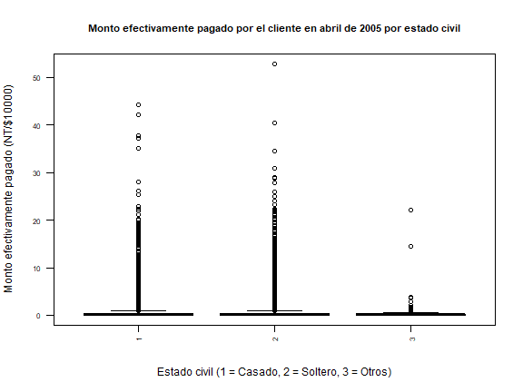

```r
boxplot(PAY_AMT6/10000 ~ MARRIAGE, data = datos_credit_visu,
        main = "Monto efectivamente pagado por el cliente en abril de 2005 por estado civil",
        las = 2,
        cex.axis = 0.7,
        cex.main = 0.9,
        xlab = "Estado civil (1 = Casado, 2 = Soltero, 3 = Otros)", ylab = "Monto efectivamente pagado (NT/$10000)",
        col = "grey90")
```

Cajas colapsadas en cero en los tres grupos, sin diferencias apreciables. Solo cambia la densidad y el alcance de la columna de atípicos: alta en casados y solteros, escasa en “Otros”, otra vez por tamaño de grupo. Adicionalmente, el grupo “Otros” está condicionado por su tamaño, al ser una muestra menor (377 de 30000 registros, aproximadamente el 1.26%).

### 3.2.5 De “default payment next month”

En esta sección se cruza la variable de respuesta `default payment next month` (indicador de si el cliente incurrió en impago al mes siguiente, convertida a factor) contra las mismas variables numéricas. Esta es la sección permite explorar visualmente qué variables podrían estar asociadas con el impago, lo cual es relevante de cara a un eventual modelo predictivo.

Se cruza `LIMIT_BAL` contra `default payment next month`, para observar si los clientes que incurren en impago tienden a tener montos de crédito otorgado distintos a los que no incurren.

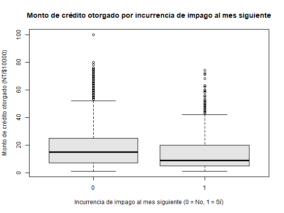

```r
boxplot(LIMIT_BAL/10000 ~ `default payment next month`, data = datos_credit_visu,
        main = "Monto de crédito otorgado por incurrencia de impago al mes siguiente",
        xlab = "Incurrencia de impago al mes siguiente (0 = No, 1 = Sí)", ylab = "Monto de crédito otorgado (NT/$10000)",
        col = "grey90")
```

La única variable con separación visible. Quienes incurren en impago tienen una caja claramente desplazada hacia abajo y más estrecha, y su bigote superior queda muy por debajo del de los cumplidores.

Se cruza `AGE` contra `default payment next month`, para observar si la edad se relaciona con la incurrencia en impago.

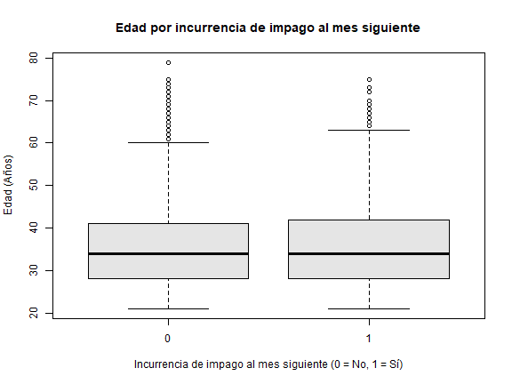

```r
boxplot(AGE ~ `default payment next month`, data = datos_credit_visu,
        main = "Edad por incurrencia de impago al mes siguiente",
        xlab = "Incurrencia de impago al mes siguiente (0 = No, 1 = Sí)", ylab = "Edad (Años)",
        col = "grey90")
```

Sin diferencia alguna: las dos cajas son prácticamente calcadas. La edad no discrimina el impago.

Se cruzan `BILL_AMT1` a `BILL_AMT6` contra `default payment next month`, generando un boxplot por mes para comparar el monto del estado de cuenta entre quienes incurrieron en impago y quienes no.

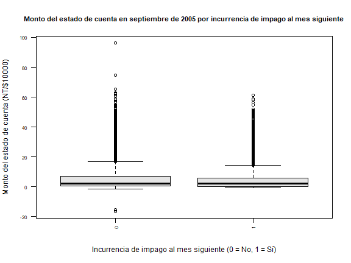

```r
boxplot(BILL_AMT1/10000 ~ `default payment next month`, data = datos_credit_visu,
        main = "Monto del estado de cuenta en septiembre de 2005 por incurrencia de impago al mes siguiente",
        las = 2,
        cex.axis = 0.7,
        cex.main = 0.9,
        xlab = "Incurrencia de impago al mes siguiente (0 = No, 1 = Sí)", ylab = "Monto del estado de cuenta (NT/$10000)",
        col = "grey90")
```

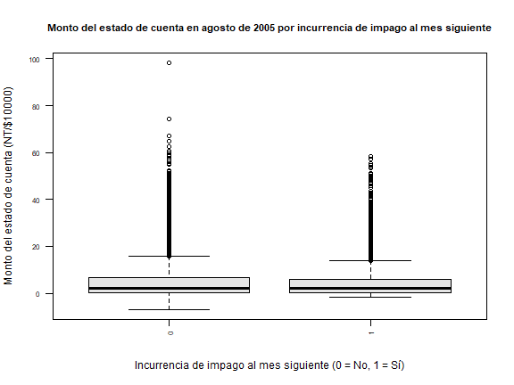

```r
boxplot(BILL_AMT2/10000 ~ `default payment next month`, data = datos_credit_visu,
        main = "Monto del estado de cuenta en agosto de 2005 por incurrencia de impago al mes siguiente",
        las = 2,
        cex.axis = 0.7,
        cex.main = 0.9,
        xlab = "Incurrencia de impago al mes siguiente (0 = No, 1 = Sí)", ylab = "Monto del estado de cuenta (NT/$10000)",
        col = "grey90")
```

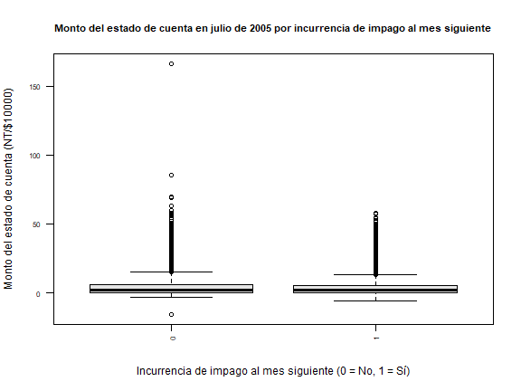

```r
boxplot(BILL_AMT3/10000 ~ `default payment next month`, data = datos_credit_visu,
        main = "Monto del estado de cuenta en julio de 2005 por incurrencia de impago al mes siguiente",
        las = 2,
        cex.axis = 0.7,
        cex.main = 0.9,
        xlab = "Incurrencia de impago al mes siguiente (0 = No, 1 = Sí)", ylab = "Monto del estado de cuenta (NT/$10000)",
        col = "grey90")
```

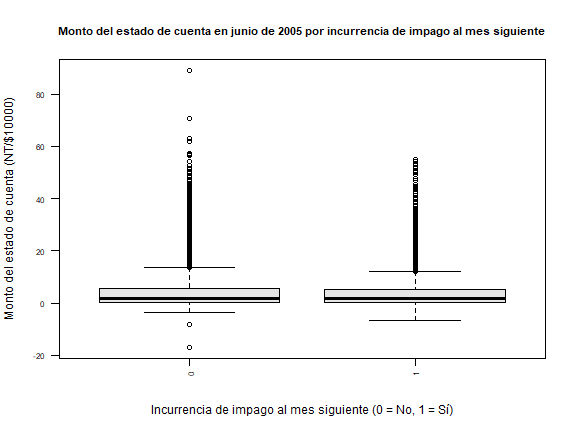

```r
boxplot(BILL_AMT4/10000 ~ `default payment next month`, data = datos_credit_visu,
        main = "Monto del estado de cuenta en junio de 2005 por incurrencia de impago al mes siguiente",
        las = 2,
        cex.axis = 0.7,
        cex.main = 0.9,
        xlab = "Incurrencia de impago al mes siguiente (0 = No, 1 = Sí)", ylab = "Monto del estado de cuenta (NT/$10000)",
        col = "grey90")
```

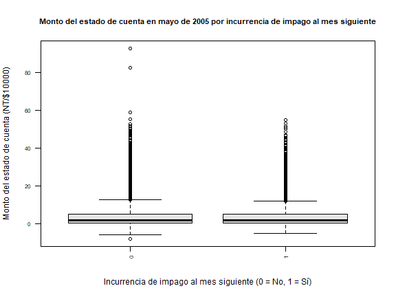

```r
boxplot(BILL_AMT5/10000 ~ `default payment next month`, data = datos_credit_visu,
        main = "Monto del estado de cuenta en mayo de 2005 por incurrencia de impago al mes siguiente",
        las = 2,
        cex.axis = 0.7,
        cex.main = 0.9,
        xlab = "Incurrencia de impago al mes siguiente (0 = No, 1 = Sí)", ylab = "Monto del estado de cuenta (NT/$10000)",
        col = "grey90")
```

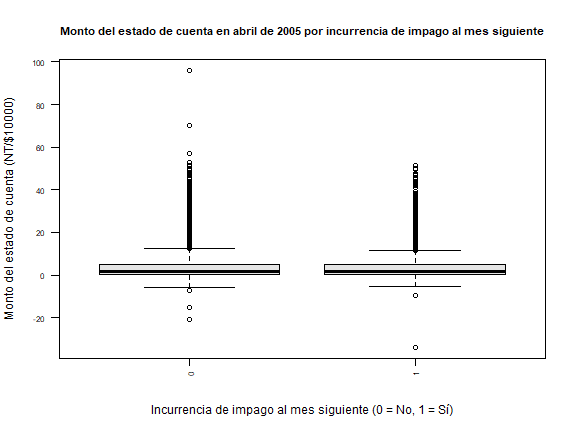

```r
boxplot(BILL_AMT6/10000 ~ `default payment next month`, data = datos_credit_visu,
        main = "Monto del estado de cuenta en abril de 2005 por incurrencia de impago al mes siguiente",
        las = 2,
        cex.axis = 0.7,
        cex.main = 0.9,
        xlab = "Incurrencia de impago al mes siguiente (0 = No, 1 = Sí)", ylab = "Monto del estado de cuenta (NT/$10000)",
        col = "grey90")
```

Cajas casi idénticas entre los dos grupos en todos los meses. Se percibe apenas que el grupo de impago llega un poco menos alto en el bigote superior y en sus extremos, pero el solapamiento es casi total. El saldo adeudado, por sí solo, no separa.

Se cruzan `PAY_AMT1` a `PAY_AMT6` contra `default payment next month`, para comparar cuánto pagaron efectivamente los clientes que incurrieron en impago frente a los que no, mes a mes.

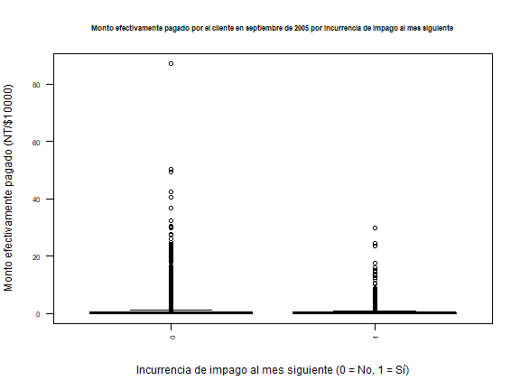

```r
boxplot(PAY_AMT1/10000 ~ `default payment next month`, data = datos_credit_visu,
        main = "Monto efectivamente pagado por el cliente en septiembre de 2005 por incurrencia de impago al mes siguiente",
        las = 2,
        cex.axis = 0.7,
        cex.main = 0.7,
        xlab = "Incurrencia de impago al mes siguiente (0 = No, 1 = Sí)", ylab = "Monto efectivamente pagado (NT/$10000)",
        col = "grey90")
```

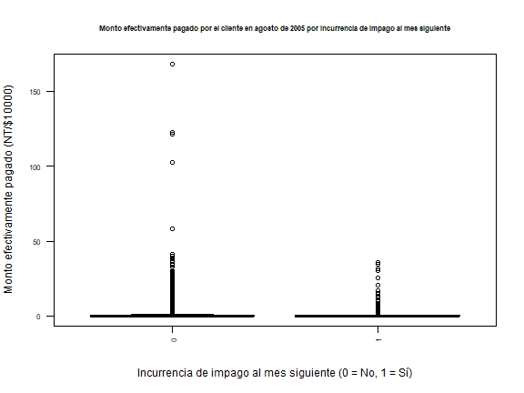

```r
boxplot(PAY_AMT2/10000 ~ `default payment next month`, data = datos_credit_visu,
        main = "Monto efectivamente pagado por el cliente en agosto de 2005 por incurrencia de impago al mes siguiente",
        las = 2,
        cex.axis = 0.7,
        cex.main = 0.7,
        xlab = "Incurrencia de impago al mes siguiente (0 = No, 1 = Sí)", ylab = "Monto efectivamente pagado (NT/$10000)",
        col = "grey90")
```

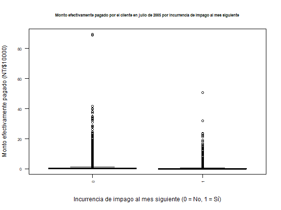

```r
boxplot(PAY_AMT3/10000 ~ `default payment next month`, data = datos_credit_visu,
        main = "Monto efectivamente pagado por el cliente en julio de 2005 por incurrencia de impago al mes siguiente",
        las = 2,
        cex.axis = 0.7,
        cex.main = 0.7,
        xlab = "Incurrencia de impago al mes siguiente (0 = No, 1 = Sí)", ylab = "Monto efectivamente pagado (NT/$10000)",
        col = "grey90")
```

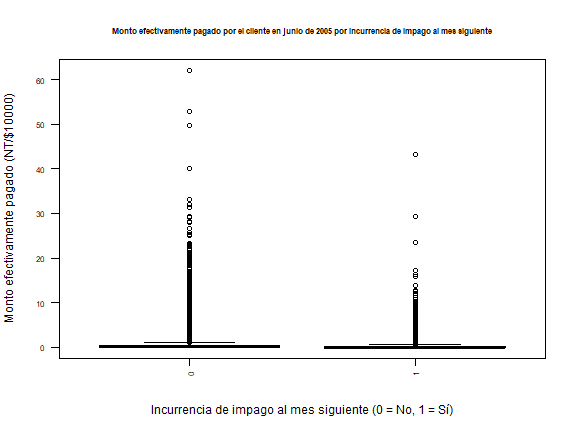

```r
boxplot(PAY_AMT4/10000 ~ `default payment next month`, data = datos_credit_visu,
        main = "Monto efectivamente pagado por el cliente en junio de 2005 por incurrencia de impago al mes siguiente",
        las = 2,
        cex.axis = 0.7,
        cex.main = 0.7,
        xlab = "Incurrencia de impago al mes siguiente (0 = No, 1 = Sí)", ylab = "Monto efectivamente pagado (NT/$10000)",
        col = "grey90")
```

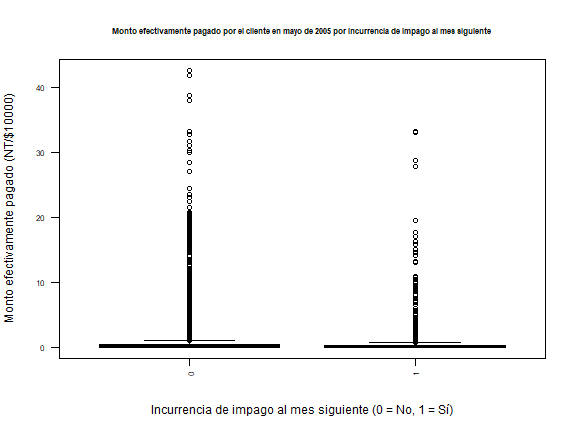

```r
boxplot(PAY_AMT5/10000 ~ `default payment next month`, data = datos_credit_visu,
        main = "Monto efectivamente pagado por el cliente en mayo de 2005 por incurrencia de impago al mes siguiente",
        las = 2,
        cex.axis = 0.7,
        cex.main = 0.7,
        xlab = "Incurrencia de impago al mes siguiente (0 = No, 1 = Sí)", ylab = "Monto efectivamente pagado (NT/$10000)",
        col = "grey90")
```

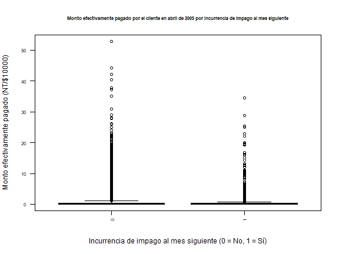

```r
boxplot(PAY_AMT6/10000 ~ `default payment next month`, data = datos_credit_visu,
        main = "Monto efectivamente pagado por el cliente en abril de 2005 por incurrencia de impago al mes siguiente",
        las = 2,
        cex.axis = 0.7,
        cex.main = 0.7,
        xlab = "Incurrencia de impago al mes siguiente (0 = No, 1 = Sí)", ylab = "Monto efectivamente pagado (NT/$10000)",
        col = "grey90")
```

Aquí sí hay un patrón consistente en la cola: los cumplidores muestran una nube de atípicos mucho más densa y que alcanza montos muy superiores. El grupo de impago tiene una cola notoriamente más corta en los seis meses. Podría sugerir que quien no paga tampoco hace abonos grandes.